# ch14

```r
a = c(91, 20, 30, 67)
ex_14_a = matrix(a, nrow = 2, ncol = 2)
# test_14 = as_tibble(ex_14_a)
x1 <- data.frame(ex_14_a)
x1["colsum",] <- apply(x1, 2, sum)
x1$rowsum <- apply(x1, 1, sum)
x1
```

|  | X1 | X2 | rowsum |
| --- | --- | --- | --- |
| 1 | 91 | 30 | 121 |
| 2 | 20 | 67 | 87 |
| colsum | 111 | 97 | 208 |

```r
Sys.setlocale('LC_ALL','C')
```

```
[1] "C"
```

```r
# calculate
# before split ginie value
a = 2*((x1[1,1]/x1[1,3])*(x1[1,2]/x1[1,3]))
b = 2*((x1[2,1]/x1[2,3])*(x1[2,2]/x1[2,3]))
# 분기 후 지니계수 1,2
c = x1[1,3]/x1[3,3]
d = x1[2,3]/x1[3,3]
# 분기 후 총 지니 계수
e = a*c + b*d
e
```

```
[1] 0.3650412
```

> 이론
- 현재는 하나의 지니계수만 구했지만 분할 알고리즘에서 모든 분기점에 대해 구하고 순도수치 최소화 분기 값 계산
  - 반복 되므로 중단 기준 필요
- 최대 깊이가 주어지는 트리 -> 훈련 데이터 과적합 우려
- 복잡도 인수 -> 순도 기준이 마지막 노드 값에 벌점이 매겨지는 방식이다.(8.1 참조) 8장가서 봐야지..
- 훈련된 트리를 예측에 사용.
- 만약예측 변수가 B=0.1로 한다면 클래스 1,2의 예측값은 0.23, 0.77 이다.
  - 해당 알고리즘 기준으로 thread 값 변화에 따라 예측값이 변한다는 의미를 얘기 해주고 싶은건지..?
- 결측값이 있다면 분류 트리는 어떻게 분리 할까?
  - 회귀 트리와 비슷한 방식으로 처리
  - 결측 정보가 없는 샘플만 처리 (8.1 참조)
  - 예측 -> 결측값이 있으면 다른 분기점 사용
- 변수가 연속형이라면?
  - 분할 프로세스는 명확히 보인다.
- 변수가 범주형이라면?
  - 일반적 통계 모형과는 다른 방법. 이항 가변수(1,0)을 만들어 구분하고 모델에 포함시킨다.
  - 새 예측 변수가 하나의 분기점을 갖게 되어 순도를 쉽게 구할 수 있다.
  - 1에 대해 0,1 로 구분하여 하나의 분기점을 만든다는 의미
- 범주형 데이터를 어떻게 처리할지 결정해야 한다.
  - 그룹 범주 방식 - 범주형 변수를 모델에 그냥 넣는 방법. 어떻게 묶을지 설정에서 결정
  - 개별 범주 방식 - 범주형 변수에 이항 가변수를 넣고 그것에 따라 나누는 것.
  - 모델을 돌려보면서 선택해야 한다. 만약 모델 예측력이 높다면 그룹 범주 방식을 사용하는게 좋다.
    - 예전에 범주형 의사결정 나무를 그리면서 개별 범주 방식으로 그렸던 기억이 있다.
- 범주형 변수의 분할 과정
  - 첫번째 분기는 17개 범주를 갖는 계약값 그룹
  - 14.3을 보았을 때, I,J,P,unkonw 그룹 그 이외의 변수로 나누었다.
  - 최적 분할을 결정 전에 범주를 결정하는 것이 합리적이다.
    - 하지만 의사결정 나무는 greedy(탐욕 알고리즘)방식을 사용한다.
  - greedy(탐욕알고리즘) -> 의사 결정 나무를 분리할 때 눈앞에 있는 범주들의 분리 값을 최우선으로 한다.
    - 마지막에 최선으로 나눠지는 것을 고려하지 않고 나눠보면서 최적의 알고리즘을 찾는다는 의미
    - 그 순간 최선의 답을 찾아나간다고 이해하면 될듯
  - 범주의 비율에 따라 정렬하는 방법
    - 14.2의 상위 그래프는 보조금 지원 성공 확률 의미. 지니계수는 정렬된 범주를 분할 하고 있음.
    - 14.2의 하위 그래프의 지니계수를 살펴보면 3개 범주 추가하는 경우 지니계수가 낮아지는 것을 확인.
    - I,M 범주 분기에서 지니 계수가 가장 낮게 나올 것으로 파악하고 이 지점에서 분기 되었을 것으로 파악.
    - I, J, P, Un 으로 구분하고 나머지 그룹으로 분리 하고 실패와 성공으로 분리 하게 된다.

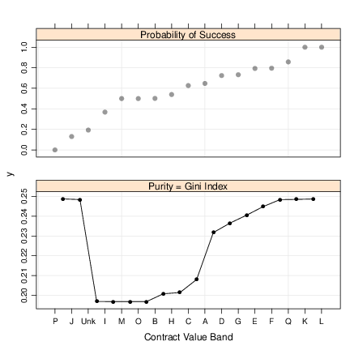

그림 14.2

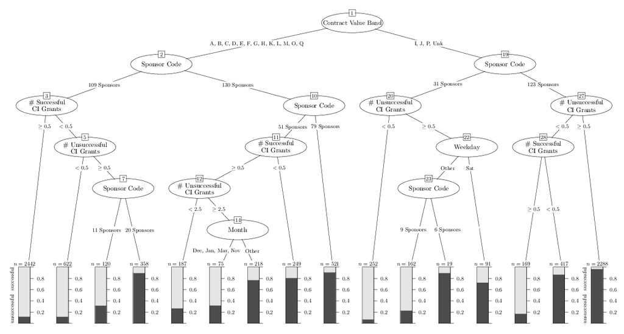

그림 14.3

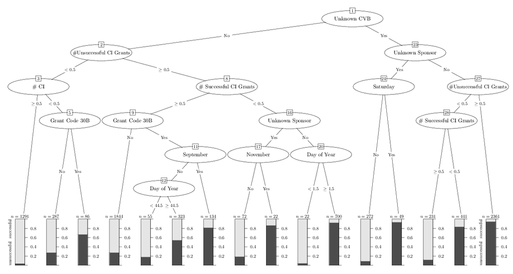

그림 14.4

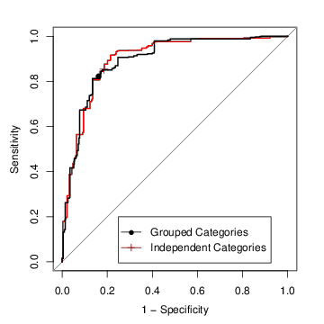

그림 14.5